# Visualização de dados do SUS

Prof. Heron OH

29 April, 2025

Olá, esta é mais uma de um conjunto de práticas em bioinformática desenvolvidas para o curso de Biomedicina da *PUC-MG*. Você pode encontrar as demais práticas [*aqui*](https://heronoh.github.io/bioinfo/aulas).

Hoje nós vamos trabalhar com dados obtidos do *Sistema Único de Saúde*, o *SUS*.

# Introdução

## Os dados do SUS

O *SUS* mantém e disponibiliza diversos sistemas de informação contendo dados relacionados à doenças, condições, causas de óbito, quadros hospitalares e características de indivíduos brasileiros. Estes dados são *anonimizados*, o que significa que não se é possível associá-los ao indivíduo fonte, desta maneira garantindo a privacidade do cidadão.

O *DATASUS* disponibiliza informações que podem servir para subsidiar análises objetivas da situação sanitária, tomadas de decisão baseadas em evidências e elaboração de programas e ações em saúde. Estes dados podem ser coletados manualmente, através da interface [*TABNET*](https://datasus.saude.gov.br/informacoes-de-saude-tabnet/), ou diversas outras fontes. Recentemente foi desenvolvido o pacote de R [*microdatasus*](https://github.com/rfsaldanha/microdatasus), que possibilita baixar os dados através de interface programática, facilitando enormemente o processo.

Existem diversos sistemas distintos, vamos conhecer os principais:

## Principais Sistemas

### SIM - Sistema de Informações sobre Mortalidade

- **Objetivo:** Registrar e monitorar os óbitos ocorridos no Brasil.
- **Fonte de dados:** Declarações de Óbito (DO).
- **Informações coletadas:**
  - Causa básica da morte (CID-10),
  - Idade,
  - Sexo,
  - Escolaridade,
  - Local de ocorrência.

O SIM é usado para análises de mortalidade por causas específicas, como doenças crônicas, infecções e causas externas (acidentes, homicídios).

### SINASC - Sistema de Informações sobre Nascidos Vivos

- **Objetivo:** Registrar todos os nascimentos vivos no país.
- **Fonte de dados:** Declarações de Nascido Vivo (DNV).
- **Informações coletadas:**
  - Peso ao nascer,
  - Idade gestacional,
  - Tipo de parto,
  - Escolaridade da mãe,
  - Local do parto.

O SINASC é importante para estudar indicadores como prematuridade, baixo peso ao nascer e saúde materno-infantil.

### Outros Sistemas Relevantes

- **SIH-SUS** (Sistema de Informações Hospitalares): registros de internações hospitalares no SUS.
- **SIA-SUS** (Sistema de Informações Ambulatoriais): registros de atendimentos ambulatoriais no SUS.
- **SINAN** (Sistema de Informação de Agravos de Notificação): monitora doenças de notificação obrigatória, como dengue, tuberculose e HIV.
- **CNES** (Cadastro Nacional de Estabelecimentos de Saúde): registra informações sobre hospitais, postos de saúde e outros estabelecimentos de saúde.

O uso integrado desses sistemas permite compreender a situação de saúde da população brasileira, monitorar tendências e embasar decisões em saúde pública.

# Prática

Nesta prática iremos explorar um subconjunto de dados do sistema SIM-DO, mais especificamente analisando óbitos relacionados ao *CID J159*: *“Pneumonia bacteriana, não especificada”*. Aproveitaremos também para revisar alguns consceitos importantes sobre a linguagem R e seu funcionamento.

## Preparação

### Carregar pacotes

```r
# para instalar o pacote, caso ainda não tenha (só se instala uma vez)
install.packages("ggplot2")
install.packages("dplyr")

# execute para carregar o pacote, caso já instalado
library("ggplot2")
library("dplyr")
```

> DICA 1: toda vez que você for reiniciar um sessão é necessário carregar os pacotes. Eles são a primeira coisa de qualquer código.

> DICA 2: Se ao carregar o pacote você tiver uma mensagem de erro como *pacote não disponível, package not available, etc*, praticamente qualquer pacore pode ser instalado com o comando intall.packages(“nome_do_pacote”).

> DICA 3: Cada pacote só precisa ser instalado uma única vez.

## Obtendo os dados

### Para a prática

Para facilitar, iremos trabalhar com um subconjunto já organizado, que deve ser baixado [aqui](https://drive.google.com/file/d/1cBdH54Ri8CYDb1wdXE5dgd6UWQqbdEiU/view?usp=sharing). Você irá fazer download do arquivo e em seguida iremos carregar esse arquivo para o R.

Vamos ver o arquivo no formato tabular clássico, nesta [tabela](https://docs.google.com/spreadsheets/d/1z46ZbQUn74_zI0IJG8RrNI096Y0VYPHebm0Ubg5CT8Y/edit?usp=drive_link).

Para as análises da desta aula prática, você pode pular a próxima sessão.

> DICA 1: Para prosseguir na análise que vamos desenvolver, copie e cole os blocos de código num novo documento do tipo *.R*.

> DICA 2: utilize a tecla **tab** para autocompletar e evitar erros!

```r
                             #complete usando a tecla TAB até chegar ao arquivo que você baixou
dados_SUS <- read.csv(file = "",
                      sep = ","
                      ) %>%
  tibble::tibble()
```

### Para outros projetos

Caso você tenha interesse em investigar outras questões sanitárias da população brasileira, você pode obter diferentes conjuntos de dados assim:

```r
# executar apenas se estiver instalando em um computador windows ----
install.packages("read.dbc", repos = "https://packagemanager.posit.co/cran/2024-07-05")

#instalar pacotes necessários ----
install.packages("remotes")
remotes::install_github("rfsaldanha/microdatasus")

library(microdatasus)

# baixar dados ----
dados_brutos_SUS <- fetch_datasus(year_start = 2020,
                       year_end = 2023,
                       uf = "MG",
                       information_system = "SIM-DO")

dados_SUS <- process_sim(dados_brutos_SUS)

dados_SUS
```

## Investigando os dados

Nossos dados estão no formato *tabular*, ou seja, organizados em *linhas* e *colunas*. As linhas são as observações de qualquer tabela. No nosso caso elas correspondem a indivíduos. Já as colunas são conjuntos definidos de informação. Cada coluna armazena um tipo de informação única, como a *idade*, *Sexo*, *município de nascimento*, entre outros. Assim, uma coluna que armazena a *idade* terá apenas valores numéricos positivos, já a de *município de nascimento* terá apenas nomes de cidade, e a coluna *Sexo* terá apenas as classes de valores *masculino*, *feminino* ou *não informado*. Desta maneira, *idade* é uma variável contínua e numérica. Por outro lado, *Sexo* é uma variável discreta e categórica. Vamos entender isso melhor.

```r
# ver a tabela de dados
dados_SUS

# qual o tamanho da tabela
dim(dados_SUS)

# qual o nome das colunas
colnames(dados_SUS)

# quais os valores de uma coluna
dados_SUS$Idade_anos
dados_SUS$Sexo

# quantas observações temos de cada tipo?
dados_SUS$Idade_anos %>% table()
dados_SUS$Sexo %>% table()


# visualizar quantas observações temos de cada tipo
dados_SUS$Idade_anos %>% table() %>% plot()
dados_SUS$Sexo %>% table() %>% barplot()



#quais as 10 primeiras observações dessa tabela
dados_SUS[1:10,]

#quais asegunda coluna
dados_SUS[,2]


#qual a média de idades?
dados_SUS$Idade_anos %>% mean(na.rm = T)
```

### Gráficos exploratórios

#### Gráfico escolaridade por Sexo

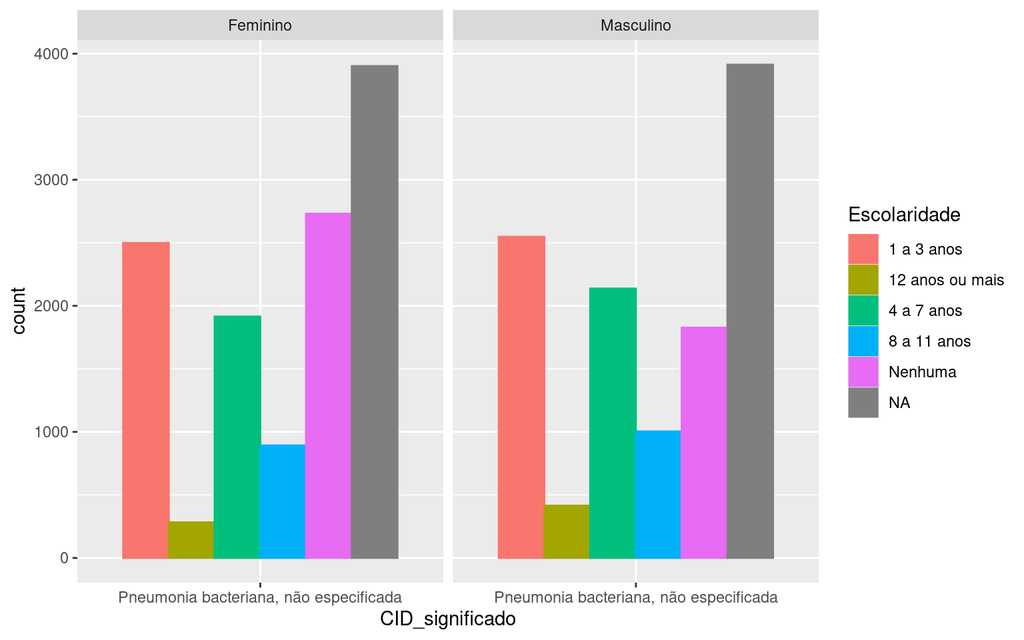

```r
# grágico escolaridade por Sexo
 dados_SUS %>%
  mutate(Idade_anos = as.numeric(Idade_anos) ) %>%
  filter(Sexo %in% c("Masculino", "Feminino")) %>%
  ggplot(aes(x = CID_significado,
             group = Escolaridade,
             col = Escolaridade,
             fill  = Escolaridade)) +
  geom_bar(stat = "count",position = "dodge") +
  facet_grid(cols = vars(Sexo))
```

#### Gráfico de Sexo e escolaridade

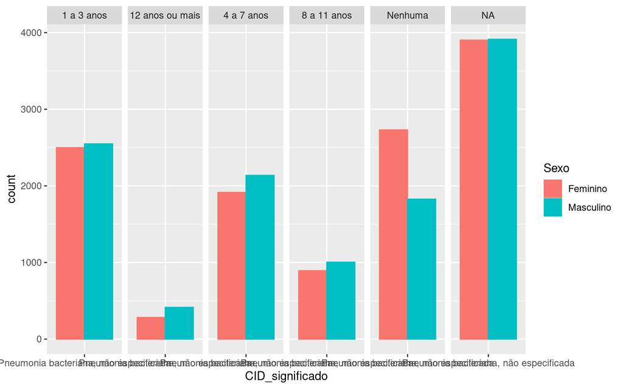

```r
 dados_SUS %>%
  mutate(Idade_anos = as.numeric(Idade_anos) ) %>%
  filter(Sexo %in% c("Masculino", "Feminino")) %>%
  ggplot(aes(x = CID_significado,
             group = Sexo,
             col = Sexo,
             fill  = Sexo)) +
  geom_bar(stat = "count",position = "dodge") +
  facet_grid(cols = vars(Escolaridade))
```

#### Gráfico aumento de mortes por grupo de escolaridade

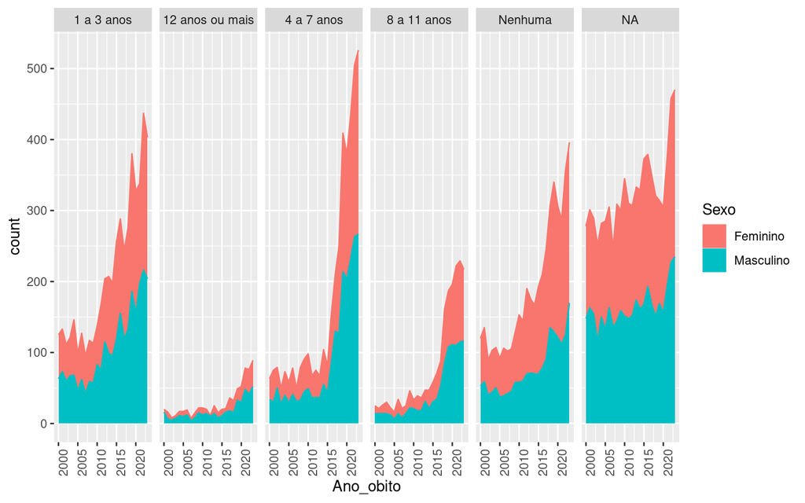

```r
 dados_SUS %>%
  filter(Sexo %in% c("Masculino", "Feminino")) %>%
  ggplot(aes(x = Ano_obito,
             group = Sexo,
             col = Sexo,
             fill  = Sexo)) +
  geom_density(stat = "count",position = "stack") +
  facet_grid(cols = vars(Escolaridade)) +
   theme(axis.text.x = element_text(angle = 90))
```

#### Gráfico aumento de mortes total

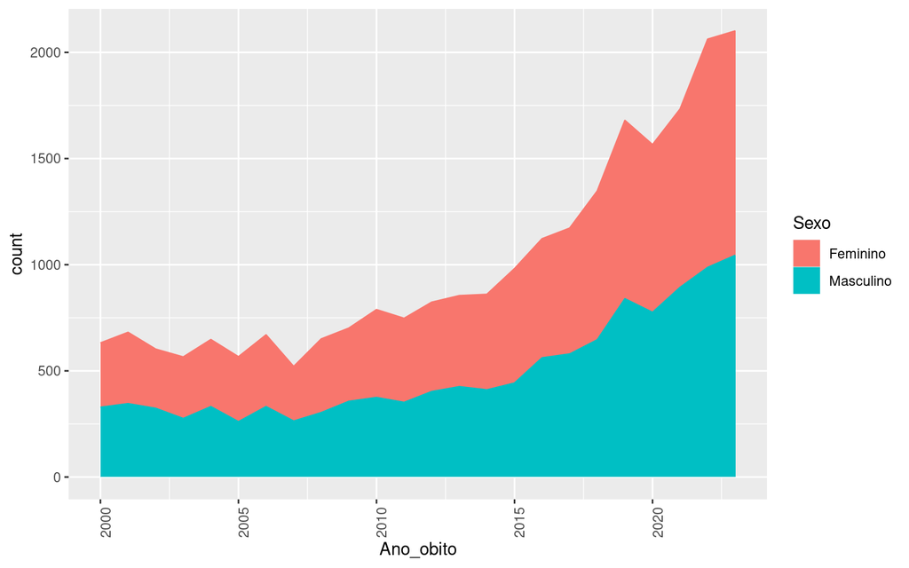

```r
 dados_SUS %>%
  filter(Sexo %in% c("Masculino", "Feminino")) %>%
  ggplot(aes(x = Ano_obito,
             group = Sexo,
             col = Sexo,
             fill  = Sexo)) +
  geom_density(stat = "count",position = "stack") +
   theme(axis.text.x = element_text(angle = 90))
```

#### Gráfico aumento de mortes por ano e estado civil

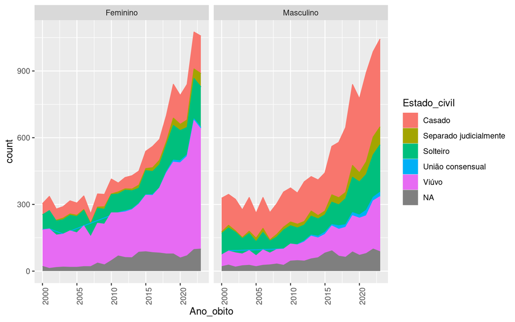

```r
 dados_SUS %>%
  filter(Sexo %in% c("Masculino", "Feminino")) %>%
  ggplot(aes(x = Ano_obito,
             group = Estado_civil,
             col = Estado_civil,
             fill  = Estado_civil)) +
  geom_density(stat = "count",position = "stack") +
   theme(axis.text.x = element_text(angle = 90)) +
  facet_grid(cols = vars(Sexo))
```

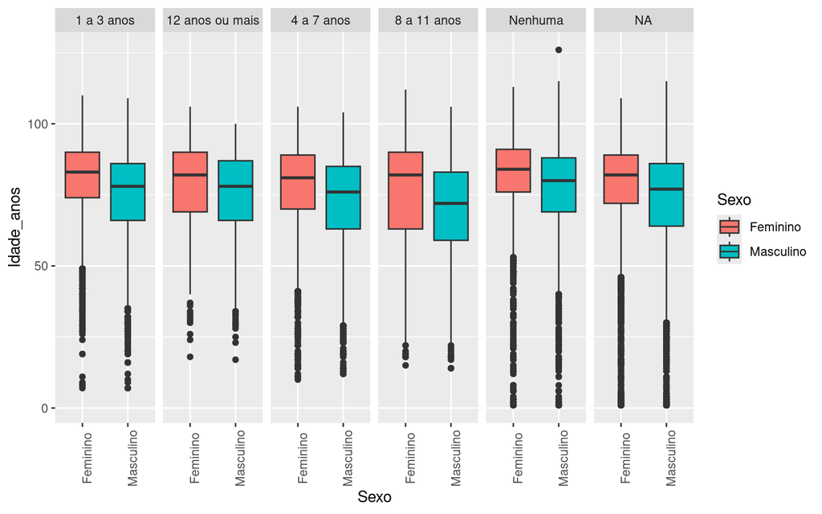

```r
 dados_SUS %>%
  filter(Sexo %in% c("Masculino", "Feminino")) %>%
  ggplot(aes(y = Idade_anos,
             x = Sexo,
             group = Sexo,
             fill  = Sexo)) +
  geom_boxplot() +
   # geom_jitter() +
   theme(axis.text.x = element_text(angle = 90)) +
  facet_grid(cols = vars(Escolaridade))
```

E por hoje ficamos por aqui!

> > > > Voltar para a [*página inicial*](https://heronoh.github.io/bioinfo)